# City Council Legislative Titles in Bargaining Unit and Comparable City Titles

February 06, 2026

## 1 Data Scientist

#### 1.0.1 Data Scientist titles

The (in house) City Council Data Scientist title, and its promotional title, Senior Data Scientist, includes the follow duties:

- Work closely with legislative attorneys and policy analysts to research policy issues, and suggest recommendations.
- Support the team in building & deploying data products & tools.
- Perform data cleaning & validation, conduct exploratory analysis, provide statistical inferences, develop models, and visualize and present findings and insights.

To be hired, this title must have a strong background in statistics and while not required, a Master’s Degree is preferred.

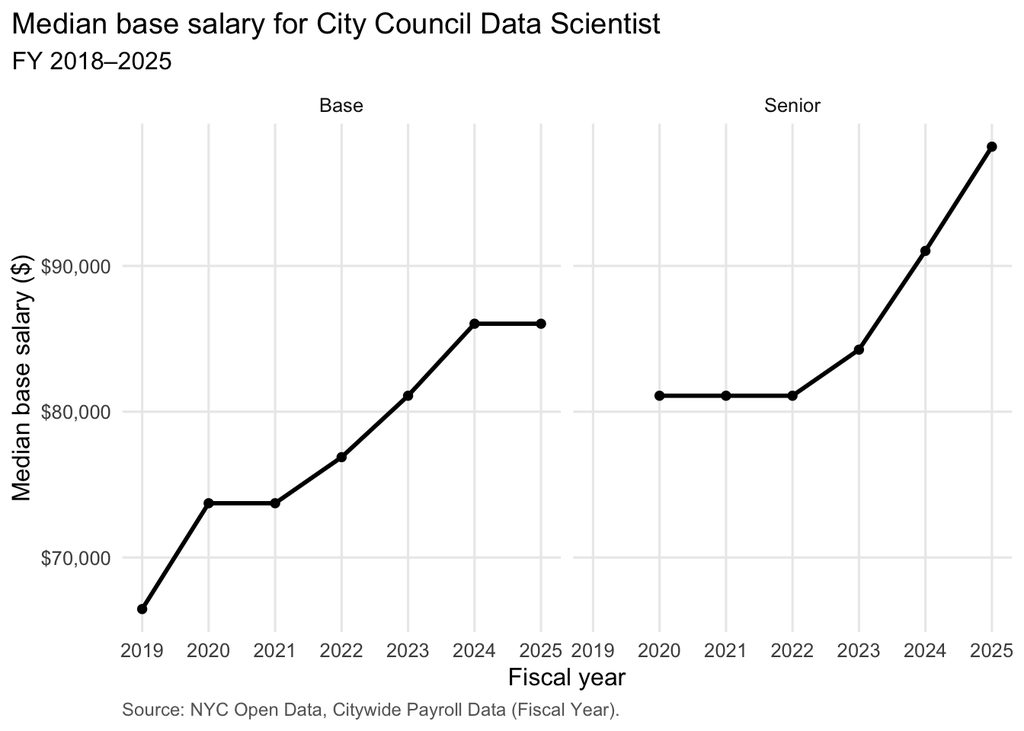

| Fiscal Year | N | Level | Median Base Salary | Average Tenure (years) |
| --- | --- | --- | --- | --- |
| 2025 | 5 | Base | $86,034 | 0.39 |
| 2025 | 3 | Senior | $98,178 | 3.85 |

City Research Scientists are used here as this title includes the ‘Data Scientist’ business title at the City. The title is responsible for independent data analysis, methodological design, and analytic reporting.

Salaries are set by a level system. We exclude Level I as it is non-technical (primarily data entry and collection roles), and the Data Science title at the City Council is technical and requires a background in statistics.

Bargaining implication: City Research Scientist ranges exceed Council data scientist medians, indicating a persistent gap for comparable technical work.

| Title | Assignment Level | Min Salary | Max Salary | Qualifications |
| --- | --- | --- | --- | --- |
| CITY RESEARCH SCIENTIST | 02 | $100,904 | $110,120 | Master's Degree and relevant experience |
| CITY RESEARCH SCIENTIST | 03 | $112,883 | $128,995 | 2 year's experience at level 02 |

## 2 Legislative Policy Analyst

#### 2.0.1 Legislative Policy Analyst

The City Council Legislative Policy Analyst title includes the following responsibilities:

- Work closely with Legislative Attorneys and Policy Analysts to analyze legal and Policy issues.
- Conduct policy research and analysis, managing relationships with stakeholders.
- Assist in the preparation of committee hearings.
- Draft committee and oversight reports.

To be hired, this title must have policy experience in a relevant area, have superior research and analytic skills, and while not required, a Master’s Degree is preferred.

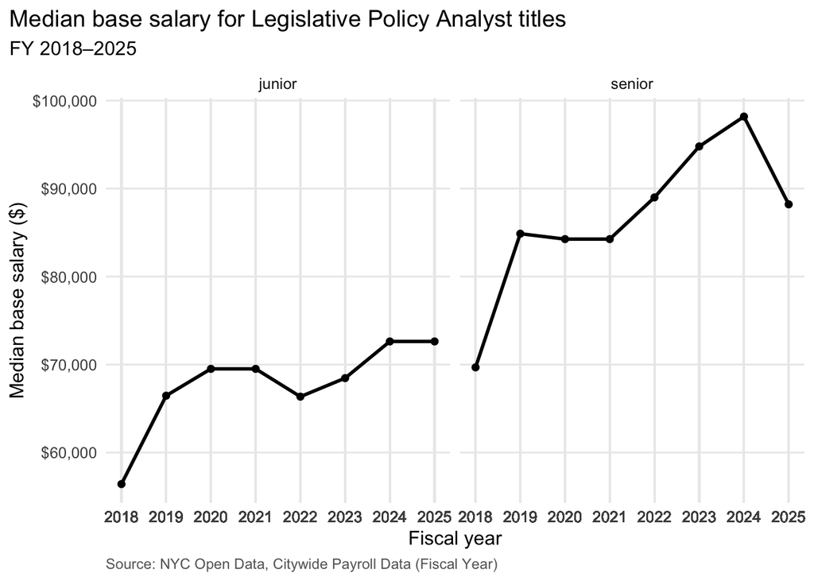

| Fiscal Year | Level | N | Median Base Salary | Average Tenure (years) |
| --- | --- | --- | --- | --- |
| 2025 | junior | 13 | $72,626 | 2.07 |
| 2025 | senior | 16 | $88,205 | 2.79 |

City Council Legislative Policy Analysts perform work that is functionally comparable to the Staff Analyst II and Associate Staff Analyst titles, which includes:

independent policy and legal analysis, research and evaluation of laws and programs, preparation of written analytical materials, and coordination with attorneys, policy staff, and stakeholders.

- Staff Analyst (levels I and II)
- Associate Staff Analyst

We remove Staff Analyst level I because the responsibilities and qualifications are considerably less than that of a Legislative Policy Analyst and use Staff Analyst level II as the level most comparable to Legislative Policy Analyst. We use Associate Staff Analyst as the most comparable City title to Senior Legislative Policy Analyst.

Bargaining implication: City titles provide higher ranges and clearer progression; Council policy analysts are paid below equivalent City roles.

| Title | Assignment Level | Min Salary | Max Salary | Qualifications |
| --- | --- | --- | --- | --- |
| STAFF ANALYST | 02 | $83,484 | $92,976 | Master's Degree + 1 year relevant experience (or Bachelor's with 3 years relevant experience) |
| ASSOCIATE STAFF ANALYST | 00 | $94,364 | $122,180 | Master's Degree + 2 years relevant experience (or Bachelor's with 4 years relevant experience) |

## 3 Legislative Counsel

#### 3.0.1 Legislative Counsel Titles and Comparable City Titles

Legislative Counsel responsibilities include:

- Drafting local legislation.
- Conducting legal research and analyzing legal and policy issues.
- Managing legislation as it moves through the legislative process.
- Advising Council Members and staff.
- Coordinating with external stakeholders.
- Staffing one or more Council committees.
- Preparing committee hearings, reports, and briefing materials.

Starting salary is tied to years out of law school.

There are two (in house) titles within the Legislative Counsel title, Legislative Counsel and the promotional title, Senior Legislative Counsel.

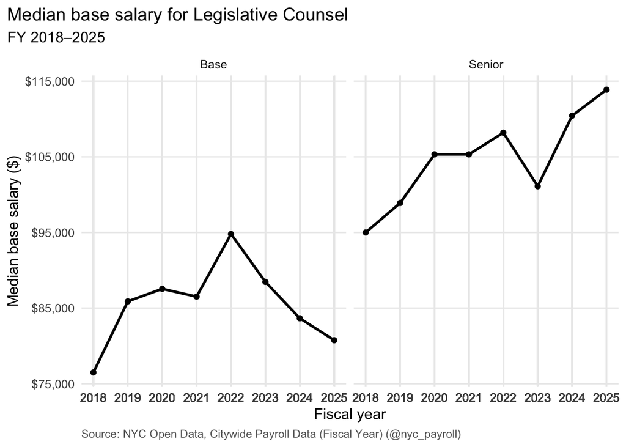

| Fiscal Year | N | Level | Median Base Salary | Average Tenure (years) |
| --- | --- | --- | --- | --- |
| 2025 | 11 | Base | $80,754 | 0.45 |
| 2025 | 25 | Senior | $113,872 | 5.14 |

Agency Attorneys are used here as the closest citywide proxy for Legislative Counsel roles, as they have similar or overlapping responsibilities, which include developing policy recommendations, serving as the liaison with external regulators, and preparing documentation for proceedings or inquiries. See New York City Open Data (2025c).

Salaries are set using defined levels and increase with tenure. See New York City Open Data (2025d).

| Title | Assignment Level | Min Salary | Max Salary | Qualifications |
| --- | --- | --- | --- | --- |
| AGENCY ATTORNEY | 01 | $84,498 | $112,172 | 0 years |
| AGENCY ATTORNEY | 02 | $95,450 | $124,381 | 1–2 years |
| AGENCY ATTORNEY | 03 | $106,404 | $136,593 | 2–3 years |
| AGENCY ATTORNEY | 04 | $111,133 | $146,052 | Greater than 3 years |

## 4 Web Developer

#### 4.0.1 Web Developer

City Council Web Developers design, build, and maintain web applications that support legislative operations, transparency, and internal workflows. Typical work includes:

- Full-stack development
- Accessibility and security practices
- Deployment and maintenance
- And collaboration with policy and data staff

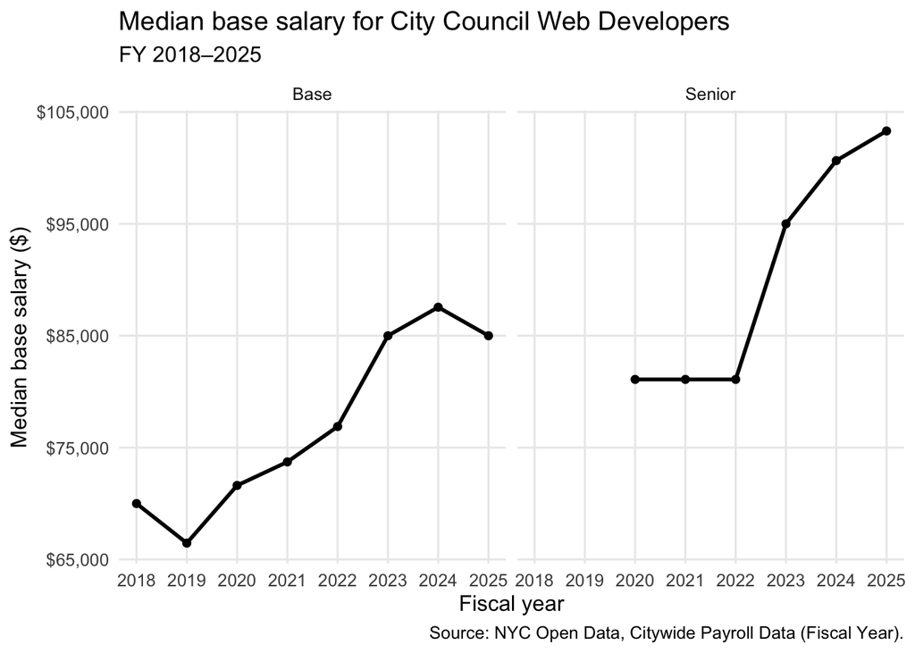

| Fiscal Year | Level | N | Median Base Salary | Average Tenure (years) |
| --- | --- | --- | --- | --- |
| 2025 | Base | 2 | $85,000 | 0.03 |
| 2025 | Senior | 6 | $103,303 | 2.60 |

Computer Specialists (Software) levels II and III

have the most comparable duties to City Council Web Developers, as they are responsible for the following with respect to software systems, websites and applications:

- Design
- Development
- Implementation
- Maintenance
- Security of software systems

Level I is excluded because it can function as an entry/trainee tier, while Council web roles generally require independent delivery and ongoing application ownership. (City of New York 2024a, 2024b)

Bargaining implication: City Computer Specialist (Software) ranges exceed Council web developer medians, indicating a persistent gap for comparable technical work.

| Title | Assignment Level | Min Salary | Max Salary |
| --- | --- | --- | --- |
| COMPUTER SPECIALIST (SOFTWARE) | Level II | $110,499 | $123,796 |
| COMPUTER SPECIALIST (SOFTWARE) | Level II | $114,090 | $127,819 |
| COMPUTER SPECIALIST (SOFTWARE) | Level III | $119,330 | $134,622 |
| COMPUTER SPECIALIST (SOFTWARE) | Level III | $123,208 | $138,997 |

## 5 Sources

City of New York. 2024a. *Computer Specialist (Software) II — MIS Developer (NYC Jobs Posting)*. https://cityjobs.nyc.gov/job/computer-specialist-software-ii-mis-developer-in-queens-jid-22843.

City of New York. 2024b. *Computer Specialist (Software), Level III (NYC Jobs Posting)*. https://cityjobs.nyc.gov/job/computer-specialist-software-level-iii-in-nyc-all-boros-jid-23319.

DC37 Local 375 Contracts. 2025a. *DC37 Local 375 Contracts (Title Code 21744)*. https://civilservicetechnicalguild.org/contracts-salary-documents.

DC37 Local 375 Contracts. 2025b. *DC37 Local 375 Contracts (Title Code 21744)*. https://civilservicetechnicalguild.org/system/files/2025-12/salary_documents.pdf.

New York City Department of Citywide Administrative Services. 2025. *Computer Specialist (Software) — Notice of Examination*. https://www.nyc.gov/assets/dcas/downloads/pdf/noes/20255056000.pdf.

New York City Open Data. 2025a. “Citywide Payroll Data (Fiscal Year).” https://data.cityofnewyork.us/City-Government/Citywide-Payroll-Data-Fiscal-Year-/k397-673e/about_data.

New York City Open Data. 2025b. “NYC Civil Service Titles.” https://data.cityofnewyork.us/City-Government/NYC-Civil-Service-Titles/nzjr-3966/about_data.

New York City Open Data. 2025c. “NYC Jobs.” https://data.cityofnewyork.us/City-Government/NYC-Jobs/pda4-rgn4/about_data.

New York City Open Data. 2025d. “Position Schedule.” https://data.cityofnewyork.us/City-Government/Position-Schedule/f4wx-5ve6/about_data.

NYC DataBook. 2025. *Agency Attorney (Title Code 30087)*. https://databook.nyc/t/30087/positions?tslug=agency-attorney.

OSA. 2024. *Staff Analyst Track*. https://www.osaunion.org/who/main.html.

Teamsters Local 237. 2025a. *Recurring Increment Payments (RIP) Schedule*. https://csbanyc.com/wp-content/uploads/2025/02/RIP-Schedule-as-of-4-18-2025.pdf.

Teamsters Local 237. 2025b. *Salary Ranges: Base Rates for CSBA Members*. https://csbanyc.com/wp-content/uploads/2025/02/Salary-Ranges-base-rate-for-CSBA-Members-effective-4-18-2025.pdf.